# **RELATION OF THE XCT COMPUTED TOMOGRAPHY WITH THE ULTRASOUND PULSE ECHO**

### Part 1/X

### **GOAL**

- Perform and measure the relation between the attenuation C-scan and the porosity projection of the XCT.
  - Measure linear correlation with window = 1mm^2
  - Measure linear correlation with window = 3mm^2

## **MATERIALS AND DATA**

There are two origins: data from the reconstructed XCT volume and the attenuation C-scan of the ultrasound volume.

- Ultrasounds data: The attenuation C-scan measured in pulse-eco.  
  XCT Scan
- XCT porosity projections with size equal to the C-scans.

## LIBRARIES

```python
# Mathematical
import scipy
import skimage
import numpy as np
import pandas as pd

import sklearn as skl
import sklearn.metrics
import sklearn.linear_model

# Operational
# import importlib
from pathlib import Path
from PIL import Image

# Visualization
import matplotlib.pyplot as plt
import napari
from napari.utils import nbscreenshot
%gui qt5
```

[output not shown]

## **1. Relation between attenuation C-scan and XCT porosity projection**

### Loading dataframes

```python
path_to_dfs_c4567 = Path(r"D:\OneDrive - Universidad Politécnica de Madrid\2_Tareas\20201210_Models_c24567\filter_dataframes")

df_c4_w1 =  pd.read_csv(path_to_dfs_c4567 / 'df_fil13coupon4_w1.csv')
df_c5_w1 =  pd.read_csv(path_to_dfs_c4567 / 'df_fil13coupon5_w1.csv')
df_c6_w1 =  pd.read_csv(path_to_dfs_c4567 / 'df_fil13coupon6_w1.csv')
df_c7_w1 =  pd.read_csv(path_to_dfs_c4567 / 'df_fil13coupon7_w1.csv')


df_c4_w3 =  pd.read_csv(path_to_dfs_c4567 / 'df_fil13coupon4_w3.csv')
df_c5_w3 =  pd.read_csv(path_to_dfs_c4567 / 'df_fil13coupon5_w3.csv')
df_c6_w3 =  pd.read_csv(path_to_dfs_c4567 / 'df_fil13coupon6_w3.csv')
df_c7_w3 =  pd.read_csv(path_to_dfs_c4567 / 'df_fil13coupon7_w3.csv')
```

### Check porosity distribution for each coupon

```
statistics of coupon 4
 count    5698.000000
mean        0.572176
std         0.684032
min         0.000000
25%         0.000000
50%         0.327692
75%         0.913462
max         4.821368
Name: porosity, dtype: float64

statistics of coupon 5
 count    5852.000000
mean        0.648383
std         0.670806
min         0.000000
25%         0.062136
50%         0.475727
75%         0.998545
max         4.202727
Name: porosity, dtype: float64

statistics of coupon 6
 count    5587.000000
mean        0.727635
std         0.743262
min         0.000000
25%         0.080889
50%         0.536889
75%         1.130222
max         4.576000
Name: porosity, dtype: float64

statistics of coupon 7
 count    5889.000000
mean        0.547984
std         0.760579
min         0.000000
25%         0.000000
50%         0.187273
75%         0.855455
max         4.721273
Name: porosity, dtype: float64
```

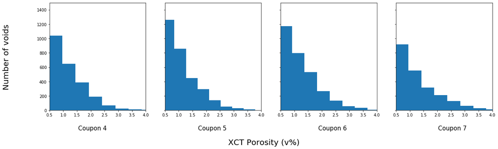

```python
l_props = [df_c4_w1,df_c5_w1,df_c6_w1,df_c7_w1]

fig,ax = plt.subplots(1,4,figsize=(20,5),sharex=True,sharey=True)
# kwargs = {'range':(2.400000e+04,3.820000e+09)}

## texts
fig.text(0.5, -0.10, 'XCT Porosity (v%)', ha='center', va='center').set_fontsize(20)
fig.text(0.05, 0.5, 'Number of voids', ha='center', va='center', rotation='vertical').set_fontsize(20)

fig.text(0.20, 0.00, 'Coupon 4', ha='center', va='center').set_fontsize(15)
fig.text(0.41, 0.00, 'Coupon 5', ha='center', va='center').set_fontsize(15)
fig.text(0.62, 0.00, 'Coupon 6', ha='center', va='center').set_fontsize(15)
fig.text(0.83, 0.00, 'Coupon 7', ha='center', va='center').set_fontsize(15)

for i,df in enumerate(l_props):
    print('statistics of coupon {} \n'.format(4+i),df['porosity'].describe(),'\n')

#     ax[i].set_yscale('log')
#     ax[i].set_xscale('log')
    ax[i].hist(df['porosity'])
    ax[i].set_xlim(0.5,4)
    ax[i].set_ylim(0,1500)
```

### Displaying images

```python
## Visualization tool
# The first image of each coupon is the
viewer = napari.Viewer()

# Images
c4_shape = (154,37)
att_cscan4 = df_c4_w1['att_12_prof'].to_numpy().reshape(c4_shape)
porosity_xct4 = df_c4_w1['porosity'].to_numpy().reshape(c4_shape)
viewer.add_image(att_cscan4)
viewer.add_image(porosity_xct4).translate = (0,45)

c5_shape = (154,38)
att_cscan5 = df_c5_w1['att_12_prof'].to_numpy().reshape(c5_shape)
porosity_xct5 = df_c5_w1['porosity'].to_numpy().reshape(c5_shape)
viewer.add_image(att_cscan5)
viewer.add_image(porosity_xct5).translate = (0,45)

c6_shape = (151,37)
att_cscan6 = df_c6_w1['att_12_prof'].to_numpy().reshape(c6_shape)
porosity_xct6 = df_c6_w1['porosity'].to_numpy().reshape(c6_shape)
viewer.add_image(att_cscan6)
viewer.add_image(porosity_xct6).translate = (0,45)

c7_shape = (151,39)
att_cscan7 = df_c7_w1['att_12_prof'].to_numpy().reshape(c7_shape)
porosity_xct7 = df_c7_w1['porosity'].to_numpy().reshape(c7_shape)
viewer.add_image(att_cscan7)
viewer.add_image(porosity_xct7).translate = (0,45)
```

[output not shown]

## **1.1 Measure lineal correlation with window side = 1mm**

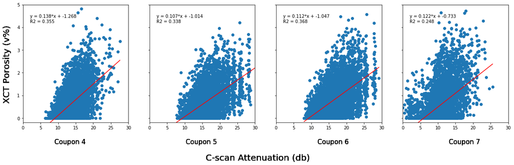

```python
## Window dataframe
l_dfs = [df_c4_w1,df_c5_w1,df_c6_w1,df_c7_w1]


fig, ax = plt.subplots(1,4,figsize=(20,5),sharey=True,sharex=True)
init1=2
init2=4.5
spacing=0.075

for i,df in enumerate(l_dfs):
    df_train = df
    X_train = df_train['att_12_prof'].to_numpy().reshape(-1,1)
    y_train = df_train['porosity']

    # lineal Regression
    linr1 = skl.linear_model.LinearRegression(fit_intercept=True)
    linr1.fit(X_train,y_train)

    # Plotting regression line
    line_por = np.linspace(np.min(X_train),np.max(X_train),2)    # Porosidad
    ylinepor = linr1.predict(line_por.reshape(-1,1))

    ax[i].scatter(X_train,y_train)

    ax[i].plot(line_por,ylinepor,'red')
    ax[i].set_ylim( ymin=-0.2, ymax=5)
    ax[i].set_xlim( xmin=0, xmax=30)


    ## Texts
    # Params
    ax[i].text(init1, init2-spacing,'y = {}*x + {}'.format(np.round(linr1.coef_[0], decimals=3),np.round(linr1.intercept_, decimals=3)))
    ax[i].text(init1, init2-4*spacing,'R2 = {}'.format(np.round(linr1.score(X_train,y_train), decimals=3)))

    # Axis titles
    fig.text(0.5, -0.10, 'C-scan Attenuation (db)', ha='center', va='center').set_fontsize(20)
    fig.text(0.10, 0.5, 'XCT Porosity (v%)', ha='center', va='center', rotation='vertical').set_fontsize(20)

    fig.text(0.20, 0.00, 'Coupon 4', ha='center', va='center').set_fontsize(15)
    fig.text(0.41, 0.00, 'Coupon 5', ha='center', va='center').set_fontsize(15)
    fig.text(0.62, 0.00, 'Coupon 6', ha='center', va='center').set_fontsize(15)
    fig.text(0.83, 0.00, 'Coupon 7', ha='center', va='center').set_fontsize(15)
```

The results of the lineal fit are displayed in this table

[output not shown]

**RESULTS:**

- **R2:** The lineal regression does not fit the wide variety of data and presents values of R2 below 0.4
- **Coefficients** The regression lines of coupon 5 and 6 present very similar coefficients. The coupon 4 one presents a slightly different slope than them.
- **Coupon 7 is different** The scatter data and lineal regression show how coupon 7 presents different behaviour than the rest of coupons.

### What if the porosity and attenuation are measured in a greater area than the pixel 1mm2?

### Displaying images with window side = 3mm

```python
## Visualization tool
# The first image of each coupon is the
viewer_w3 = napari.Viewer()

# Images
c4_shape = (154,37)
att_cscan4 = df_c4_w3['att_12'].to_numpy().reshape(c4_shape)
porosity_xct4 = df_c4_w3['porosity'].to_numpy().reshape(c4_shape)
viewer_w3.add_image(att_cscan4)
viewer_w3.add_image(porosity_xct4).translate = (0,45)

c5_shape = (154,38)
att_cscan5 = df_c5_w3['att_12'].to_numpy().reshape(c5_shape)
porosity_xct5 = df_c5_w3['porosity'].to_numpy().reshape(c5_shape)
viewer_w3.add_image(att_cscan5)
viewer_w3.add_image(porosity_xct5).translate = (0,45)

c6_shape = (151,37)
att_cscan6 = df_c6_w3['att_12'].to_numpy().reshape(c6_shape)
porosity_xct6 = df_c6_w3['porosity'].to_numpy().reshape(c6_shape)
viewer_w3.add_image(att_cscan6)
viewer_w3.add_image(porosity_xct6).translate = (0,45)

c7_shape = (151,39)
att_cscan7 = df_c7_w3['att_12'].to_numpy().reshape(c7_shape)
porosity_xct7 = df_c7_w3['porosity'].to_numpy().reshape(c7_shape)
viewer_w3.add_image(att_cscan7)
viewer_w3.add_image(porosity_xct7).translate = (0,45)
```

## **1.2 Measure lineal correlation with window side = 3mm**

```python
df_train.iloc[::3].shape
```

```
(1963, 2)
```

```python
## Window dataframe
l_dfs = [df_c4_w3,
         df_c5_w3,
         df_c6_w3,
         df_c7_w3]


fig, ax = plt.subplots(1,4,figsize=(20,5),sharey=True,sharex=True)
init1=2
init2=2.8
spacing=0.075

for i,df in enumerate(l_dfs):
    df_train = df
    X_train = df_train['att_12'].to_numpy().reshape(-1,1)
    y_train = df_train['porosity']

    # lineal Regression
    linr1 = skl.linear_model.LinearRegression(fit_intercept=True)
    linr1.fit(X_train,y_train)

    # Plotting regression line
    line_por = np.linspace(np.min(X_train),np.max(X_train),2)    # Porosidad
    ylinepor = linr1.predict(line_por.reshape(-1,1))

    ax[i].scatter(X_train,y_train)

    ax[i].plot(line_por,ylinepor,'red')
    ax[i].set_ylim( ymin=-0.2, ymax=3)
    ax[i].set_xlim( xmin=0, xmax=30)


    ## Texts
    # Params
    ax[i].text(init1, init2-spacing,'y = {}*x + {}'.format(np.round(linr1.coef_[0], decimals=3),np.round(linr1.intercept_, decimals=3)))
    ax[i].text(init1, init2-4*spacing,'R2 = {}'.format(np.round(linr1.score(X_train,y_train), decimals=3)))

    # Axis titles
    fig.text(0.5, -0.10, 'C-scan Attenuation (db)', ha='center', va='center').set_fontsize(20)
    fig.text(0.10, 0.5, 'XCT Porosity (v%)', ha='center', va='center', rotation='vertical').set_fontsize(20)

    fig.text(0.20, 0.00, 'Coupon 4', ha='center', va='center').set_fontsize(15)
    fig.text(0.41, 0.00, 'Coupon 5', ha='center', va='center').set_fontsize(15)
    fig.text(0.62, 0.00, 'Coupon 6', ha='center', va='center').set_fontsize(15)
    fig.text(0.83, 0.00, 'Coupon 7', ha='center', va='center').set_fontsize(15)
```

[output not shown]

The results of the lineal fit are displayed in this table

|  | R2 | a | b |
| --- | --- | --- | --- |
| c4 | 0.67 | 0.14 | -1.14 |
| c5 | 0.65 | 0.11 | -0.99 |
| c6 | 0.68 | 0.11 | -1.03 |
| c7 | 0.45 | 0.12 | -0.65 |

**RESULTS:**

**CONCLUSIONS:** Relation of the Computed Tomography (XCT) and the Ultrasound Techniques (UT)

* It is possible to relate the XCT and the ultrasound techniques. * The projection of the reconstructed porosity and the attenuation images are lineally correlated with a sliding window of size equal to 3mm2 for three out of the four coupons. * The coupon 7 presents a different behaviour. The lineal model fails for registers with porosity above 1% * It is clear that the window size affects since the window equal to 1mm2 had R2 below 0.4. The effects of window size needs of further study

## Images

### **Window side = 1mm**

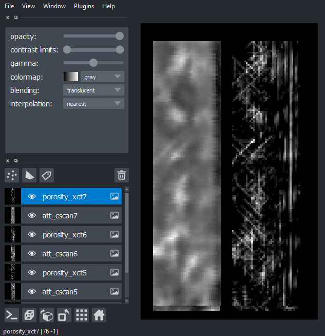

```python
nbscreenshot(viewer)
```

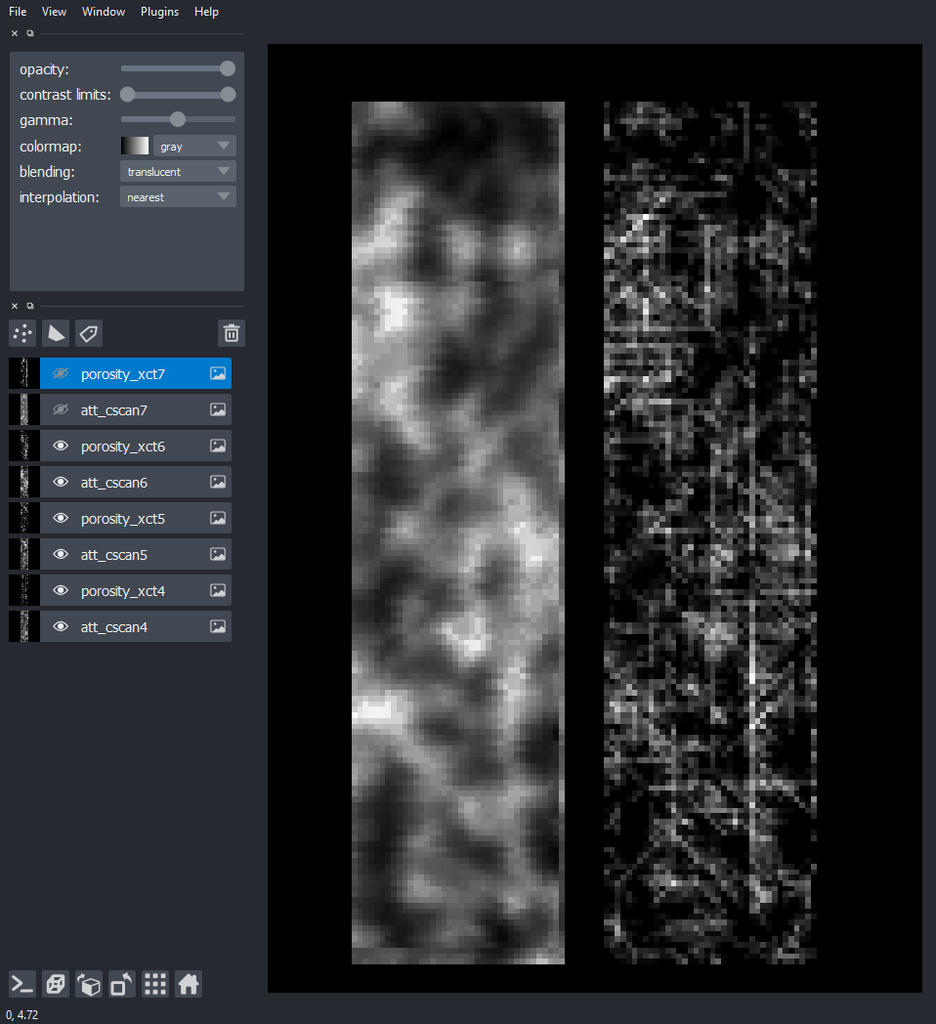

```python
nbscreenshot(viewer)
```

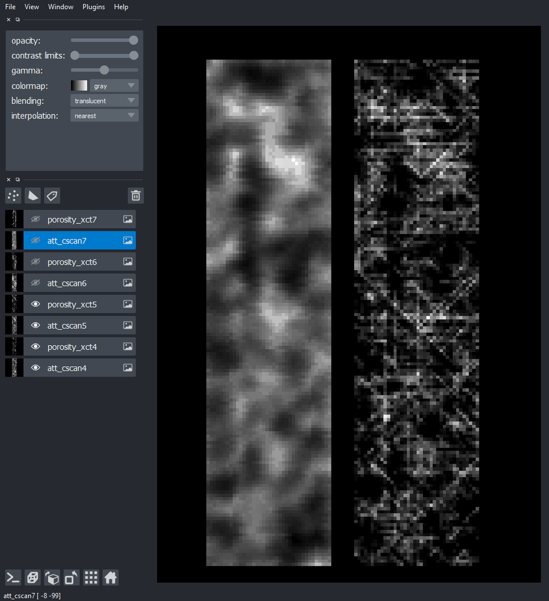

```python
nbscreenshot(viewer)
```

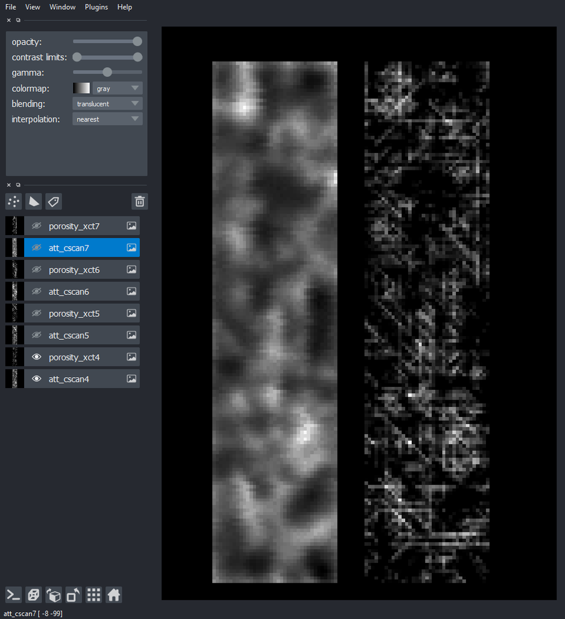

```python
nbscreenshot(viewer)
```

### **Window side = 3mm**

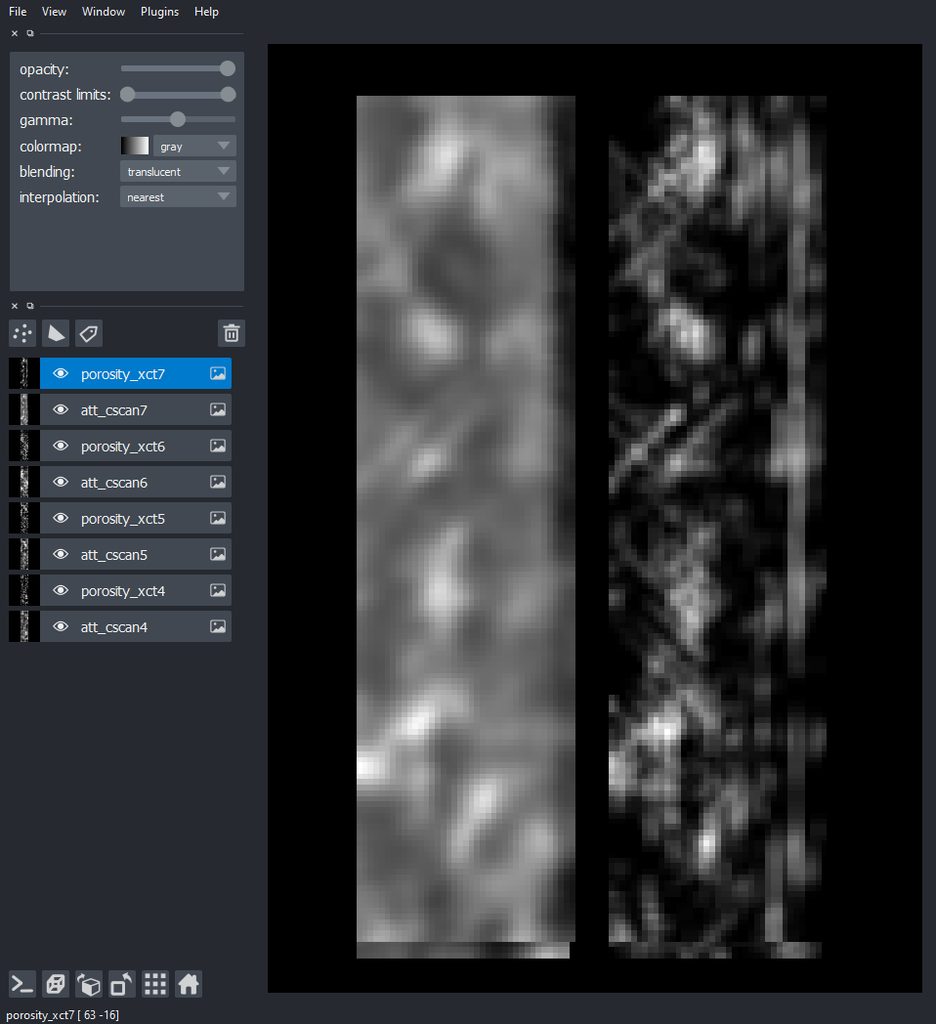

```python
nbscreenshot(viewer_w3)
```

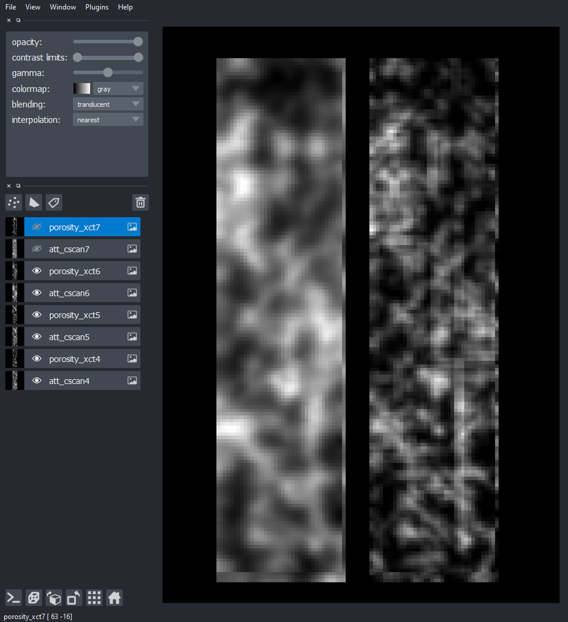

```python
nbscreenshot(viewer_w3)
```

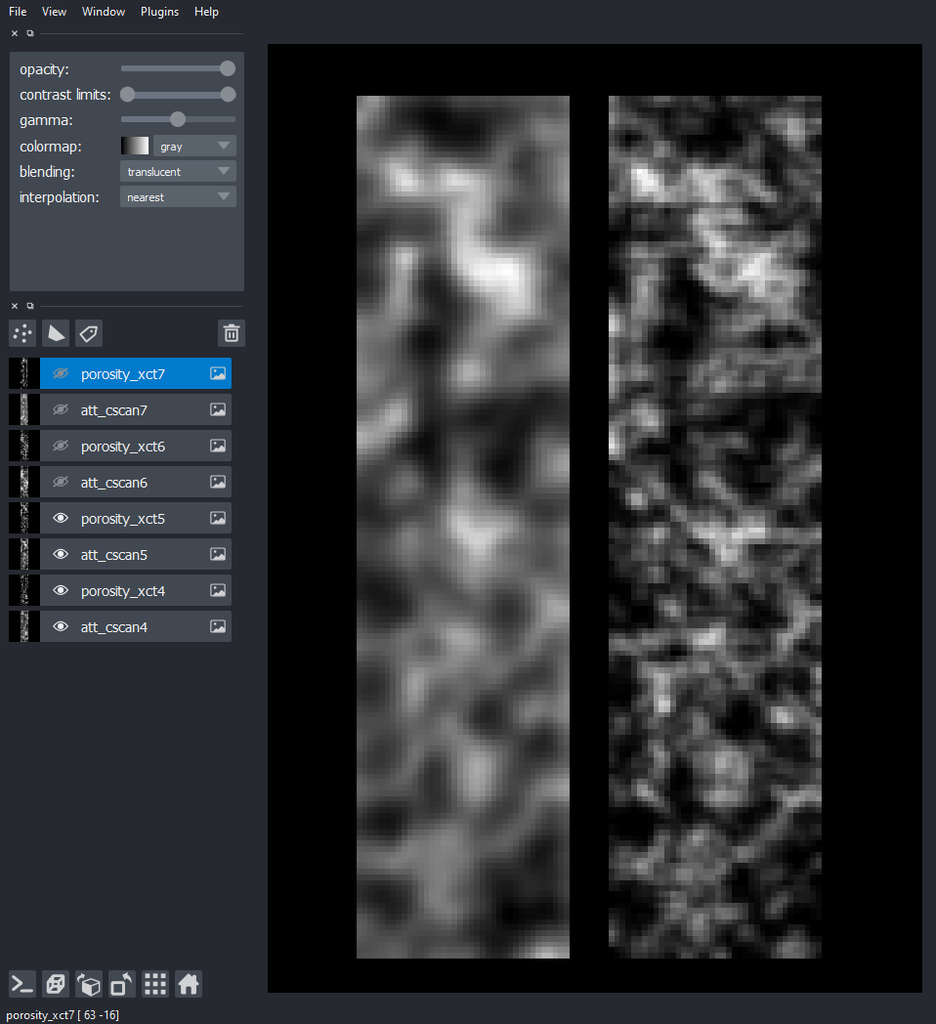

```python
nbscreenshot(viewer_w3)
```

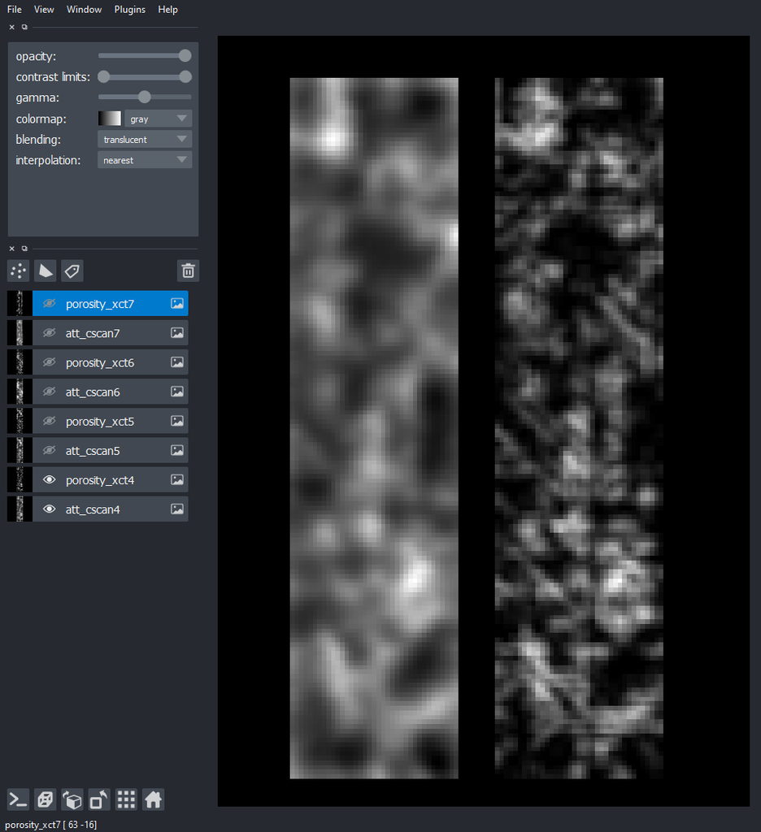

```python
nbscreenshot(viewer_w3)
```